Tormi Reinon

========================================================

# Introduction

The red wines data set contains information on 1599 red wines. The goal of my analysis was to understand what physicochemical properties determine the quality of a wine. It turned out that there is no single property or a compound that determines the quality of a wine. However, some factors, like alcohol percent and volatile acidity were moderately correlated with wine quality.

# Reflection

I struggled most with multivariate analysis, since the correlations were rather low and it was difficult for me to make meaningful and clear plots showing how two properties affect wine quality. I overcame this problem by generating heat maps of average quality by splitting two variables into bins based on quantile values. This analysis is not ideal because it is affected by certain level of randomness, especially when the number of bins is high and number of items falling into each bin is low.

For future analysis it would be interesting to see whether there are certain combinations of characteristics that specify a high quality wine. Machine learning and preferably a larger data set are probably necessary for this task.

# Univariate Plots Section

```
## [1] 1599   13
```

```
## 'data.frame':    1599 obs. of  13 variables:
##  $ X                   : int  1 2 3 4 5 6 7 8 9 10 ...
##  $ fixed.acidity       : num  7.4 7.8 7.8 11.2 7.4 7.4 7.9 7.3 7.8 7.5 ...
##  $ volatile.acidity    : num  0.7 0.88 0.76 0.28 0.7 0.66 0.6 0.65 0.58 0.5 ...
##  $ citric.acid         : num  0 0 0.04 0.56 0 0 0.06 0 0.02 0.36 ...
##  $ residual.sugar      : num  1.9 2.6 2.3 1.9 1.9 1.8 1.6 1.2 2 6.1 ...
##  $ chlorides           : num  0.076 0.098 0.092 0.075 0.076 0.075 0.069 0.065 0.073 0.071 ...
##  $ free.sulfur.dioxide : num  11 25 15 17 11 13 15 15 9 17 ...
##  $ total.sulfur.dioxide: num  34 67 54 60 34 40 59 21 18 102 ...
##  $ density             : num  0.998 0.997 0.997 0.998 0.998 ...
##  $ pH                  : num  3.51 3.2 3.26 3.16 3.51 3.51 3.3 3.39 3.36 3.35 ...
##  $ sulphates           : num  0.56 0.68 0.65 0.58 0.56 0.56 0.46 0.47 0.57 0.8 ...
##  $ alcohol             : num  9.4 9.8 9.8 9.8 9.4 9.4 9.4 10 9.5 10.5 ...
##  $ quality             : int  5 5 5 6 5 5 5 7 7 5 ...
```

```
##        X          fixed.acidity   volatile.acidity  citric.acid
##  Min.   :   1.0   Min.   : 4.60   Min.   :0.1200   Min.   :0.000
##  1st Qu.: 400.5   1st Qu.: 7.10   1st Qu.:0.3900   1st Qu.:0.090
##  Median : 800.0   Median : 7.90   Median :0.5200   Median :0.260
##  Mean   : 800.0   Mean   : 8.32   Mean   :0.5278   Mean   :0.271
##  3rd Qu.:1199.5   3rd Qu.: 9.20   3rd Qu.:0.6400   3rd Qu.:0.420
##  Max.   :1599.0   Max.   :15.90   Max.   :1.5800   Max.   :1.000
##  residual.sugar     chlorides       free.sulfur.dioxide
##  Min.   : 0.900   Min.   :0.01200   Min.   : 1.00
##  1st Qu.: 1.900   1st Qu.:0.07000   1st Qu.: 7.00
##  Median : 2.200   Median :0.07900   Median :14.00
##  Mean   : 2.539   Mean   :0.08747   Mean   :15.87
##  3rd Qu.: 2.600   3rd Qu.:0.09000   3rd Qu.:21.00
##  Max.   :15.500   Max.   :0.61100   Max.   :72.00
##  total.sulfur.dioxide    density             pH          sulphates
##  Min.   :  6.00       Min.   :0.9901   Min.   :2.740   Min.   :0.3300
##  1st Qu.: 22.00       1st Qu.:0.9956   1st Qu.:3.210   1st Qu.:0.5500
##  Median : 38.00       Median :0.9968   Median :3.310   Median :0.6200
##  Mean   : 46.47       Mean   :0.9967   Mean   :3.311   Mean   :0.6581
##  3rd Qu.: 62.00       3rd Qu.:0.9978   3rd Qu.:3.400   3rd Qu.:0.7300
##  Max.   :289.00       Max.   :1.0037   Max.   :4.010   Max.   :2.0000
##     alcohol         quality
##  Min.   : 8.40   Min.   :3.000
##  1st Qu.: 9.50   1st Qu.:5.000
##  Median :10.20   Median :6.000
##  Mean   :10.42   Mean   :5.636
##  3rd Qu.:11.10   3rd Qu.:6.000
##  Max.   :14.90   Max.   :8.000
```

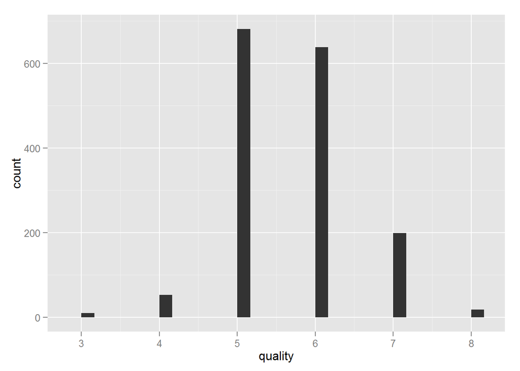

```
##
##   3   4   5   6   7   8
##  10  53 681 638 199  18
```

```
##
##    3    4    5    6    7    8
##  0.6  3.3 42.6 39.9 12.4  1.1
```

Distribution of quality scores is close to normal distribution. Most wines have intermediate quality scores 5 or 6 (80% combined). There are little number of the highest and the lowest scores (18 wines with score 8 and 10 wines with score 3).

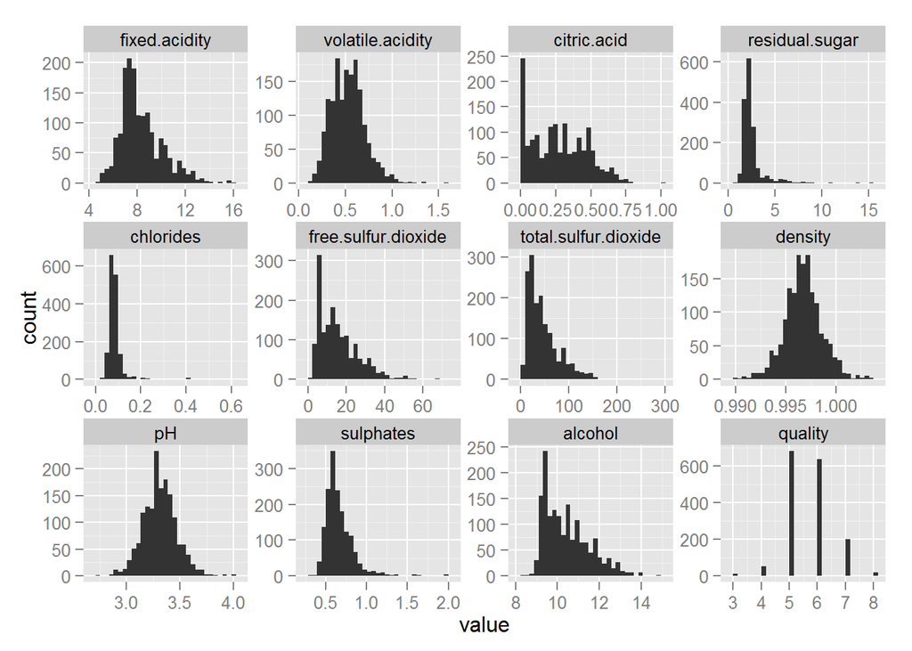

There are values of 11 chemical or physical properties that describe each red wine.

```
##    Min. 1st Qu.  Median    Mean 3rd Qu.    Max.
##    4.60    7.10    7.90    8.32    9.20   15.90
```

```
##  [1] 13.7 13.8 14.0 14.3 15.0 15.0 15.5 15.5 15.6 15.6 15.9
```

```
##    Min. 1st Qu.  Median    Mean 3rd Qu.    Max.
##  0.1200  0.3900  0.5200  0.5278  0.6400  1.5800
```

```
##  [1] 1.040 1.070 1.090 1.115 1.130 1.180 1.185 1.240 1.330 1.330 1.580
```

Values of fixed acidity are between 4.6 and 15.9 g/l, most values are between 6 and 12, with some outliers on the larger end. Distribution of volatile acidity is also similar; with most values lying between 0.25 and 0.85 g/l, however around ten outliers have values over 1.0.

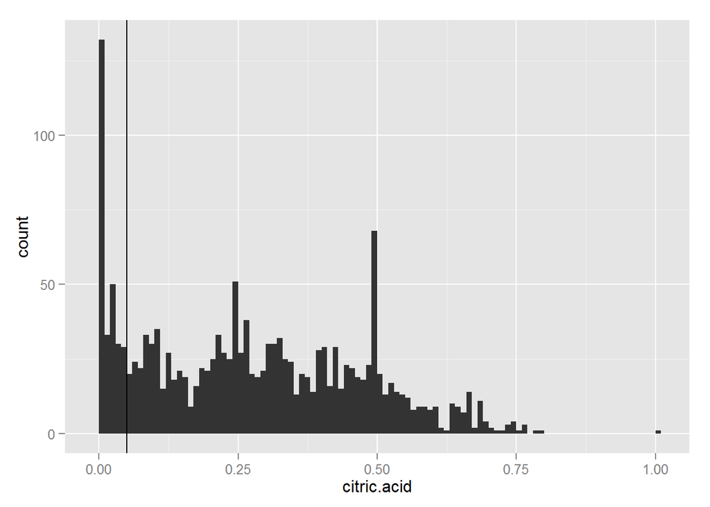

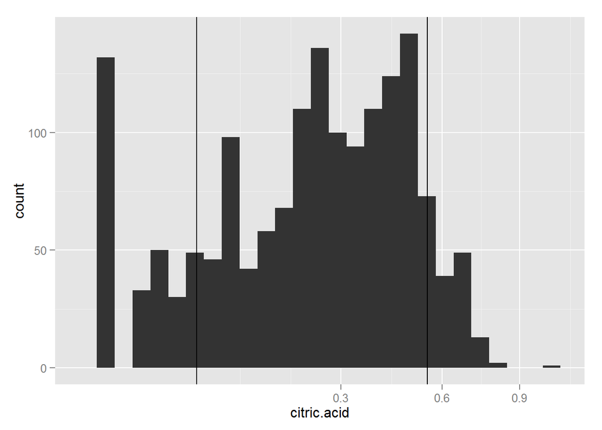

```
## wines$citric.factor: low
##    Min. 1st Qu.  Median    Mean 3rd Qu.    Max.
## 0.00000 0.00000 0.01000 0.01237 0.02000 0.04000
## --------------------------------------------------------
## wines$citric.factor: moderate
##    Min. 1st Qu.  Median    Mean 3rd Qu.    Max.
##  0.0500  0.1800  0.2900  0.2924  0.4200  0.5500
## --------------------------------------------------------
## wines$citric.factor: high
##    Min. 1st Qu.  Median    Mean 3rd Qu.    Max.
##   0.560   0.590   0.640   0.643   0.680   1.000
```

```
## wines$citric.factor: low
## [1] 274  14
## --------------------------------------------------------
## wines$citric.factor: moderate
## [1] 1204   14
## --------------------------------------------------------
## wines$citric.factor: high
## [1] 121  14
```

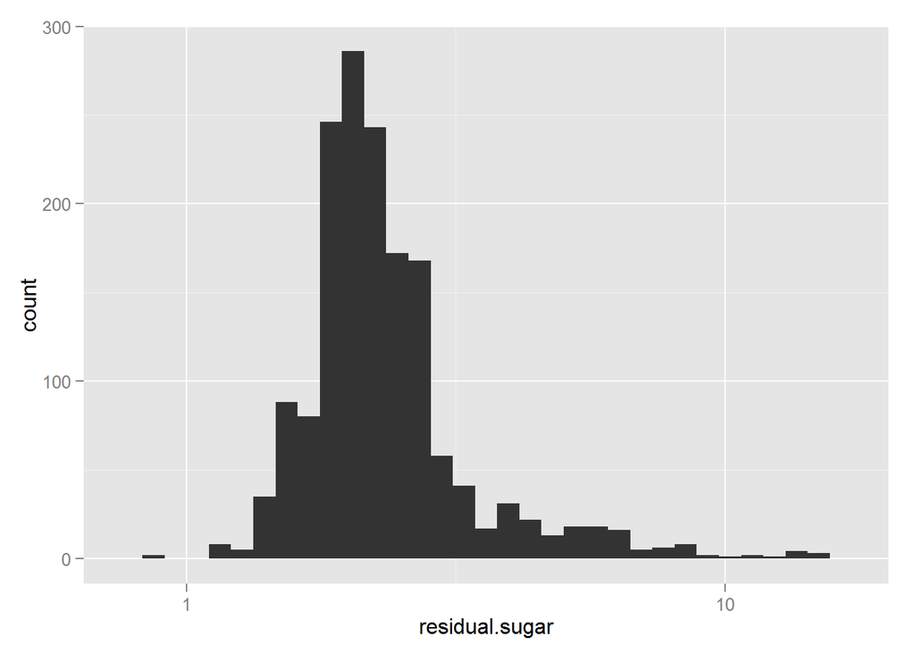

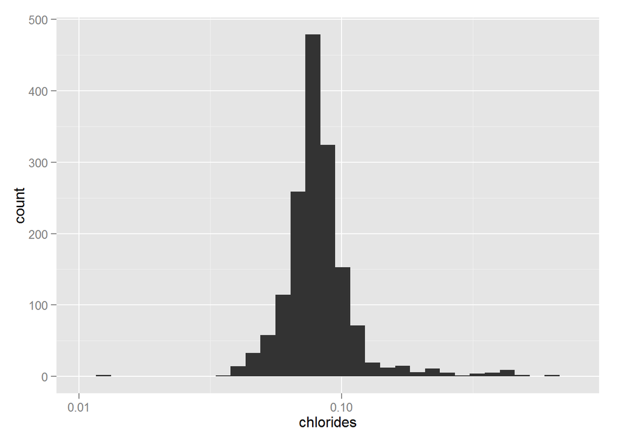

```
##  [1]  8.1  8.1  8.3  8.3  8.3  8.6  8.8  8.8  8.9  9.0 10.7 11.0 11.0 12.9
## [15] 13.4 13.8 13.8 13.9 15.4 15.4 15.5
```

```
##  [1] 0.337 0.341 0.343 0.358 0.360 0.368 0.369 0.387 0.401 0.403 0.413
## [12] 0.414 0.414 0.415 0.415 0.415 0.422 0.464 0.467 0.610 0.611
```

Distributions of chloride and residual sugars are similar, with most wines having respective values close to population means (0.087 for chlorides and 2.54 for residual sugar). Both distributions are tailing on the larger sides.

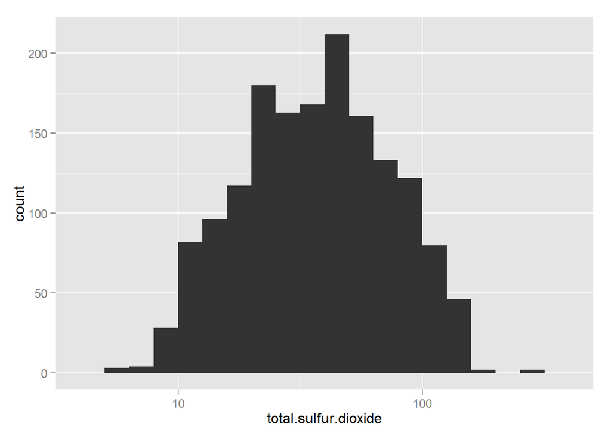